# ICE Annina 10x sequencing analysis - ML predictions of extended human data

Author

Vladyslav Korobeynyk at Jessberger/Robinsonlab, UZH

Published

October 26, 2026

**Note**

In this script we are building glmnet model using gene expression as covariate to model donor’s age

**What this script does:** loads the donor-level pseudobulk `SingleCellExperiment` objects of the extended human DLPFC lifespan cohort produced by `01_human_extended_Processing.qmd` and the DEA tables from `02_human_extended_Analysis_pseudobulk_Level.qmd`, then for each cell type (IN, EN) trains a lasso (glmnet, gaussian family) model that predicts chronological Age from pseudobulk gene expression. The donors are split 80/20 into train/test sets, repeated across `n_times` random seeds; lambda is chosen by internal cross-validation on the training set. Predicted-vs-true-age plots, CV error plots, gene coefficient tables and feature-stability plots are produced and saved.

- Each sample is one donor (no metacells), so every test set consists of donors the model never saw. The leave-patients-out strategy of `03_human_ML_predictions_human.qmd` (needed there because metacells of one patient could fall into both train and test sets) is therefore not needed here.
- Donors are filtered to the same age range as in the DEA notebook (`min_age`–`max_age`; keep these params identical in both notebooks).
- Gene selection for the model keeps genes with ≥ `min_gene_count` counts in at least `min_fraction_samples_expressing` of donors.
- The number of cells summed per donor explains a large share of expression variance (see the DEA notebook). glmnet only sees expression, so predictions are also plotted against `log_n_cells` to check that the model does not predict age through it.

# Setup

```r
options(future.globals.maxSize = 8000 * 1024^2)
suppressMessages({
  library(scater)
  library(dplyr)
  library(caret)
  library(purrr)
  library(ggpubr)
  library(ggplot2)
  library(magrittr)
  library(glmnet)
  library(knitr)
  library(DT)
})
source(params$helper_functions_path)
dir.create(params$glmnet_output_dir, recursive = TRUE, showWarnings = FALSE)

set.seed(1)
n_times = params$n_times
```

# Load data and params

```r
#' Load one pseudobulk SCE, apply the age filter used in the DEA notebook, log-normalise
#' and add the metadata column names expected by the shared glmnet helpers
load_pseudobulk_sce = function(path, min_age, max_age) {
  sce = readRDS(path)
  sce$Age = as.numeric(sce$Age)
  sce = sce[, !is.na(sce$Age) & sce$Age >= min_age & sce$Age < max_age]
  sce = sce[rowSums(counts(sce)) > 0, ]
  sce = logNormCounts(sce)

  # build_seed_result() (helper_functions.R) attaches Sex/Diagnosis/Sample_Source to
  # the predictions; here Diagnosis = Control status, Sample_Source = Brain_bank
  sce$Diagnosis = factor(sce$Control)
  sce$Sample_Source = factor(sce$Brain_bank)
  sce$Sex = factor(sce$Sex)
  sce$log_n_cells = log(sce$n_cells)
  sce
}

# -----#
# IN
# -----#
pseudobulk_sce_IN = load_pseudobulk_sce(
  file.path(params$pseudobulk_dir, "pseudobulk_sce_IN_human_extended.RDS"), params$min_age, params$max_age
)
DEA_pseudobulk_IN = read.csv(file.path(params$dea_dir, "DEA_pseudobulk_iN_age_human_extended.csv"), row.names = 1)

# -----#
# EN
# -----#
pseudobulk_sce_EN = load_pseudobulk_sce(
  file.path(params$pseudobulk_dir, "pseudobulk_sce_EN_human_extended.RDS"), params$min_age, params$max_age
)
DEA_pseudobulk_EN = read.csv(file.path(params$dea_dir, "DEA_pseudobulk_exN_age_human_extended.csv"), row.names = 1)

c(IN_donors = ncol(pseudobulk_sce_IN), EN_donors = ncol(pseudobulk_sce_EN))
```

```
IN_donors EN_donors
      165       165
```

```r
summary(pseudobulk_sce_IN$Age); summary(pseudobulk_sce_EN$Age)
```

```
   Min. 1st Qu.  Median    Mean 3rd Qu.    Max.
  30.00   43.00   53.00   53.13   63.00   79.00
```

```
   Min. 1st Qu.  Median    Mean 3rd Qu.    Max.
  30.00   43.00   53.00   53.15   63.00   79.00
```

# Helper functions

The modelling is run identically for IN and EN.

```r
#' Keep genes with >= min_count counts in at least min_fraction_samples of donors
#' Rationale: reduces noise/feature count before feeding into glmnet
filter_genes_min_expression = function(sce, min_count = params$min_gene_count,
                                       min_fraction_samples = params$min_fraction_samples_expressing) {
  keep = rowSums(counts(sce) >= min_count) >= (min_fraction_samples * ncol(sce))
  sce[keep, ]
}

#' Predicted vs. true age scatter + regression line + R^2
#' color_by: optional column name in df to map to point color
plot_pred_vs_age = function(df, color_by = NULL, title = "Predicted vs chronological Age per donor") {
  if (is.null(color_by)) {
    p = ggplot(df, aes(x = chronological_age, y = pred)) +
      geom_point(color = "skyblue") +
      geom_smooth(method = "lm", color = "black", linetype = "dashed") +
      stat_regline_equation(aes(label = after_stat(rr.label)), color = "black", show.legend = FALSE)
  } else if (is.numeric(df[[color_by]])) {
    # continuous covariate (e.g. log_n_cells): colour gradient, single regression line
    p = ggplot(df, aes(x = chronological_age, y = pred)) +
      geom_point(aes(color = .data[[color_by]]), size = 1) +
      geom_smooth(method = "lm", color = "black", linetype = "dashed") +
      scale_color_viridis_c()
  } else {
    p = ggplot(df, aes(x = chronological_age, y = pred, color = .data[[color_by]])) +
      geom_point(size = 0.75) +
      geom_smooth(method = "lm", linetype = "dashed") + # one line per group (color inherited)
      stat_regline_equation(aes(label = after_stat(rr.label)), show.legend = FALSE)
  }
  p +
    labs(y = "Predicted Age", x = "True Age") +
    ggtitle(title) +
    theme_bw()
}

#' Prediction error (predicted - true age) vs number of cells per donor: if the model
#' used cell number as a proxy for age, the error would trend with log_n_cells
plot_error_vs_ncells = function(df) {
  ggplot(df, aes(x = log_n_cells, y = pred - chronological_age)) +
    geom_point(alpha = 0.6) +
    geom_smooth(method = "lm", color = "black", linetype = "dashed") +
    stat_cor(method = "spearman") +
    labs(x = "log(number of cells per donor)", y = "Predicted - true Age") +
    ggtitle("Prediction error vs number of cells") +
    theme_bw()
}

#' CV MSE across training seeds, with the mean test-set MSE.
plot_cv_mse_across_seeds = function(model_params_list, n_times, title = "MSE of CV") {
  df = lapply(model_params_list, function(x) x[c("lambda.min", "MSE_cv", "MSE_cv_sd", "seed", "MSE_test")]) %>%
    do.call(rbind.data.frame, .)

  summary_row = data.frame(
    lambda.min = mean(df$lambda.min),
    MSE_cv = mean(df$MSE_test),
    MSE_cv_sd = sd(df$MSE_test),
    seed = "test_data_acrossSeeds"
  )
  df = rbind(df %>% select(!MSE_test), summary_row)
  df$seed = factor(df$seed, levels = c(as.character(seq_len(n_times)), "test_data_acrossSeeds"))

  ggplot(df, aes(x = seed, y = MSE_cv, color = lambda.min)) +
    geom_point() +
    geom_errorbar(aes(ymin = MSE_cv - MSE_cv_sd, ymax = MSE_cv + MSE_cv_sd)) +
    ggtitle(title)
}

#' Feature stability across seeds: how often + how strongly each gene was selected
plot_feature_stability = function(coefs, n_times) {
  coef_df = coefs %>% select(-mean)
  summary_df = data.frame(
    gene = rownames(coef_df),
    selection_freq = rowSums(coef_df != 0),
    mean_coef = rowMeans(coef_df),
    sd_coef = apply(coef_df, 1, sd)
  ) %>%
    filter(selection_freq >= n_times / 2) %>%
    arrange(desc(selection_freq), desc(abs(mean_coef))) %>%
    slice_head(n = 50)

  ggplot(summary_df, aes(x = reorder(gene, mean_coef), y = mean_coef)) +
    geom_errorbar(aes(ymin = mean_coef - sd_coef, ymax = mean_coef + sd_coef),
                  width = 0.2, color = "gray60", alpha = 0.7) +
    geom_point(color = "gray20", size = 2.5) +
    coord_flip() +
    theme_minimal() +
    labs(
      title = paste0("Feature Stability across ", n_times, " Seeds"),
      subtitle = paste0("Genes selected in at least half of the seeds, ranked by selection frequency and coefficient"),
      x = "Gene", y = "Average Coefficient"
    )
}

#' 80/20 train/test split over donors, repeated across n_times seeds
run_glmnet_age_model = function(sce, n_times, label, output_dir, DEA_table, top_n_genes) {

  sce = filter_genes_min_expression(sce)
  logcounts_df = as.data.frame(t(as.matrix(logcounts(sce))))
  logcounts_df$label = sce$Age
  meta = colData(sce)

  lst_predictions = train_glmnet_model(df = logcounts_df, model_family = "gaussian",
                                       metadata = meta, n_times = n_times)

  # Predicted vs true age (rownames of the predictions are the test donors)
  df_pred = lapply(lst_predictions$lst, function(x) {
    x$predictions %>% mutate(donor = rownames(x$predictions))
  }) %>% do.call(rbind.data.frame, .)
  df_pred$log_n_cells = meta[df_pred$donor, "log_n_cells"]

  print(plot_pred_vs_age(df_pred))

  # CV error across seeds
  print(plot_cv_mse_across_seeds(lapply(lst_predictions$lst, `[[`, "model_params"), n_times))

  # MSE across lambdas (regularization path, last seed)
  plot(lst_predictions$cvfit)
  title(main = "lambda regularization vs MSE", line = 2.5)

  # Coefficients across seeds
  coefs = lapply(lst_predictions$lst, function(x) x$coeffs$gene_imp) %>%
    do.call(cbind.data.frame, .)
  colnames(coefs) = names(lst_predictions$lst)
  coefs = coefs[rowMeans(coefs) != 0, ] %>% mutate(mean = rowMeans(.))
  coefs = coefs[rownames(coefs) != "(Intercept)", ] %>% round(2)  # remove intercept

  print(datatable(coefs))
  write.table(coefs, file.path(output_dir, paste0("coefs_glmnet_human_extended_", label, ".txt")))

  # Predicted vs true age, colored by covariate
  print(plot_pred_vs_age(df_pred, color_by = "sex"))
  print(plot_pred_vs_age(df_pred, color_by = "diagnosis"))
  print(plot_pred_vs_age(df_pred, color_by = "sample_source"))
  print(plot_pred_vs_age(df_pred, color_by = "log_n_cells"))
  print(plot_error_vs_ncells(df_pred))

  # Feature stability across seeds
  print(plot_feature_stability(coefs, n_times))

  # Expression of top up/down genes across Age, by a few covariates
  genes = unique(c(
    head(rownames(coefs)[order(coefs$mean)], top_n_genes),
    head(rownames(coefs)[order(coefs$mean, decreasing = TRUE)], top_n_genes)
  ))
  stopifnot(all(genes %in% rownames(sce)))

  print(
    plotExpression(sce, features = genes, x = "Age", ncol = 4, colour_by = "Sample_Source") +
      geom_smooth(method = "lm")
  )
  print(datatable(DEA_table[intersect(genes, rownames(DEA_table)), ] %>% select(-gene) %>% round(4)))

  print(
    plotExpression(sce, features = genes, x = "Age", ncol = 4, colour_by = "Sex") +
      geom_smooth(method = "lm")
  )
  print(
    plotExpression(sce, features = genes, x = "Age", ncol = 4, colour_by = "log_n_cells") +
      geom_smooth(method = "lm")
  )

  invisible(list(coefs = coefs, predictions = lst_predictions))
}
```

# Age prediction

**IN**

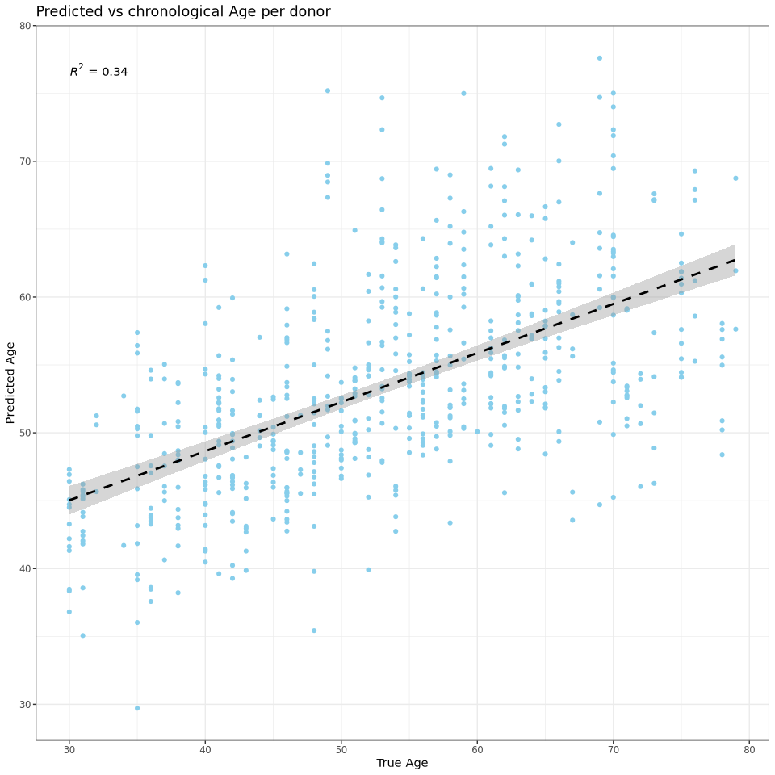

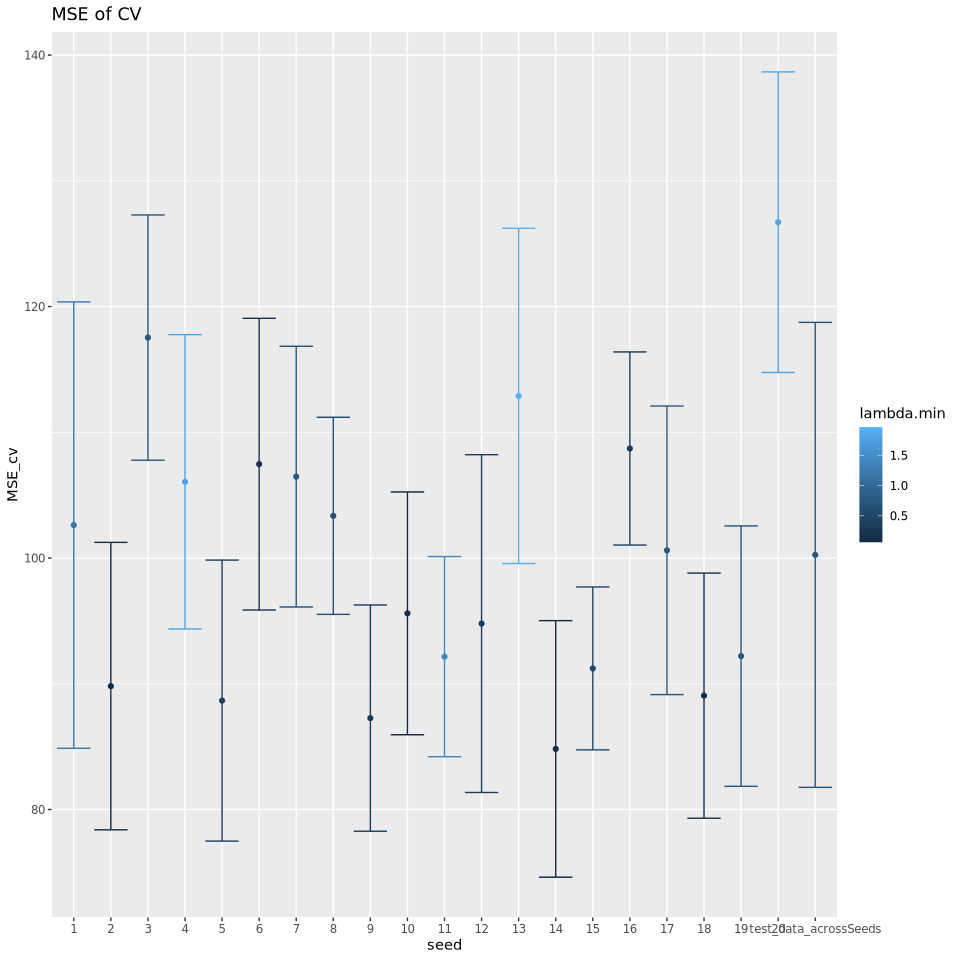

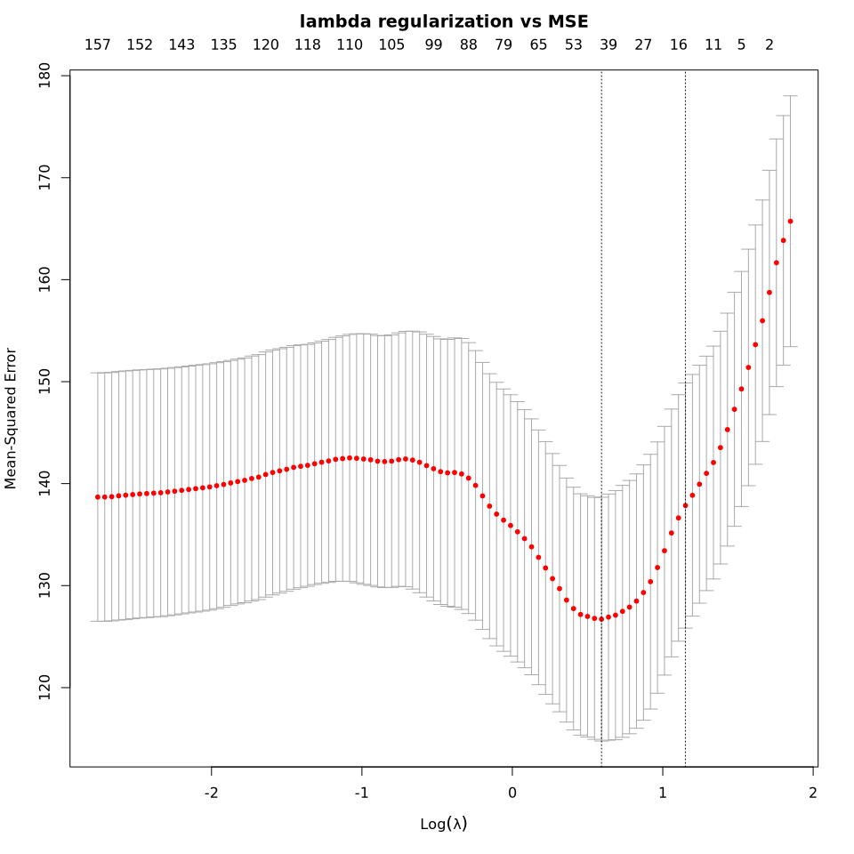

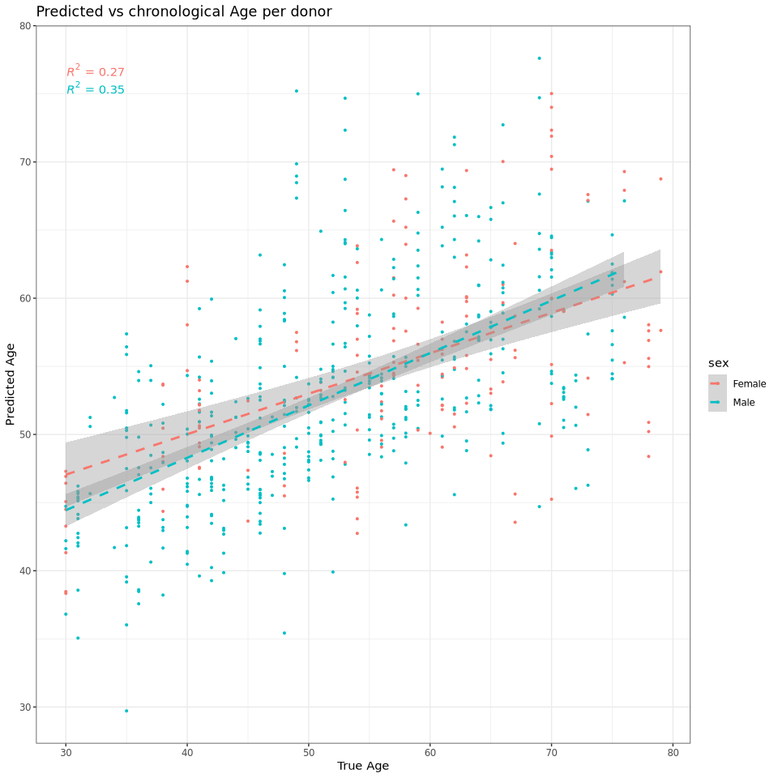

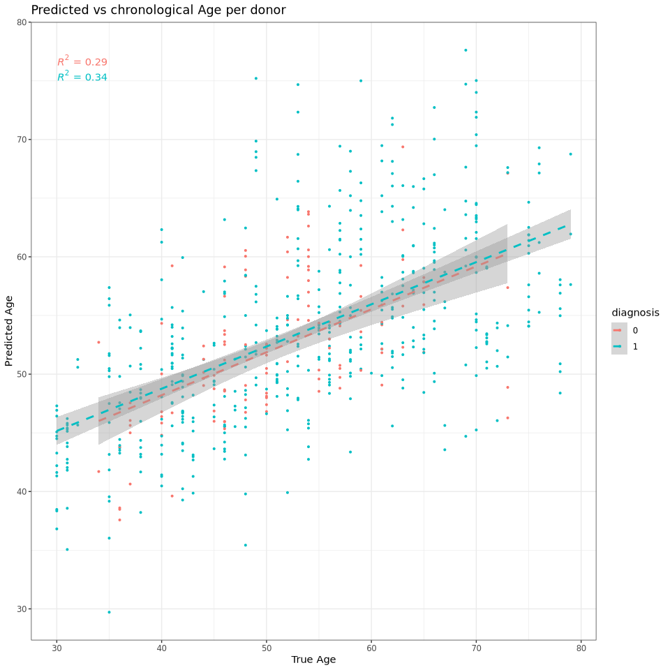

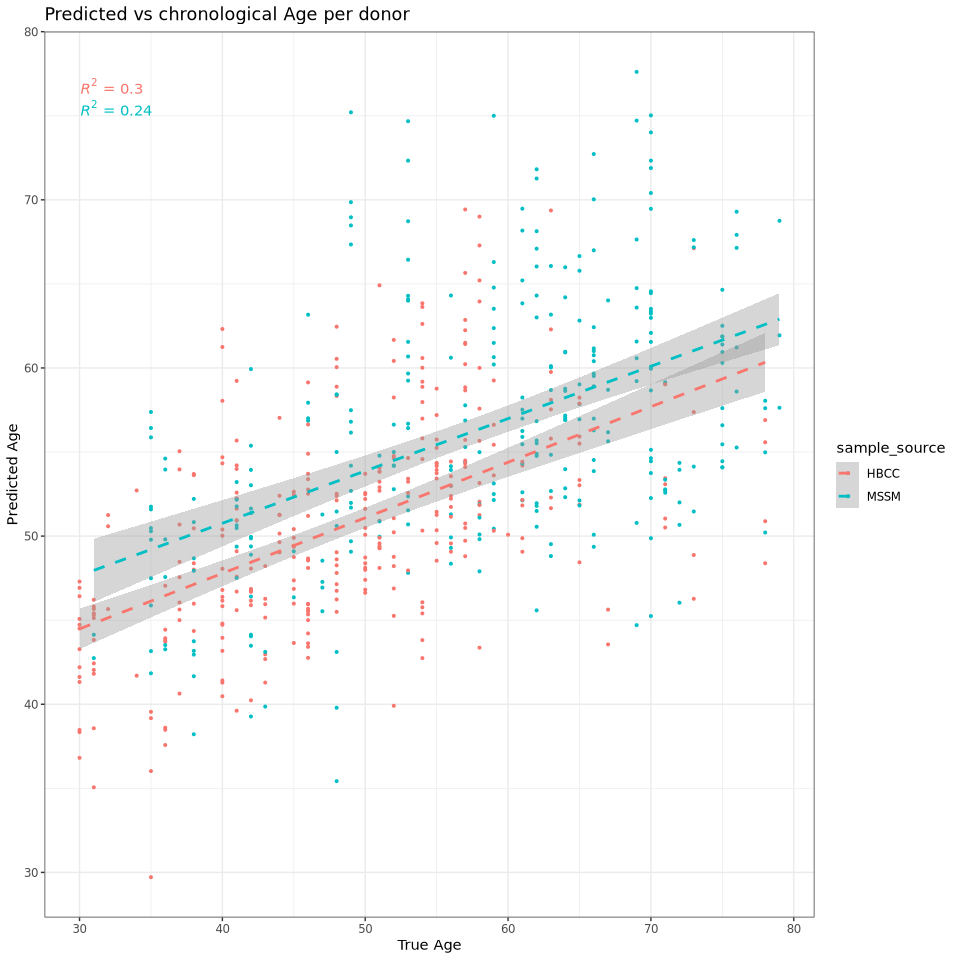

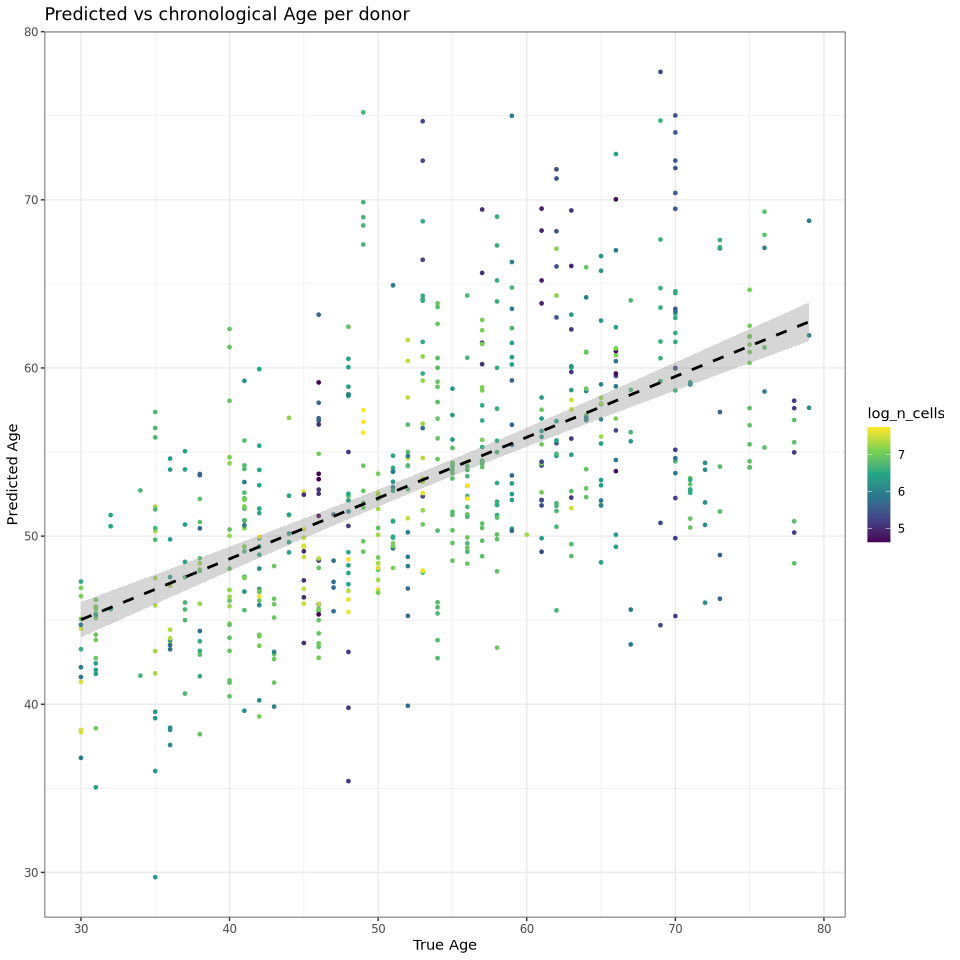

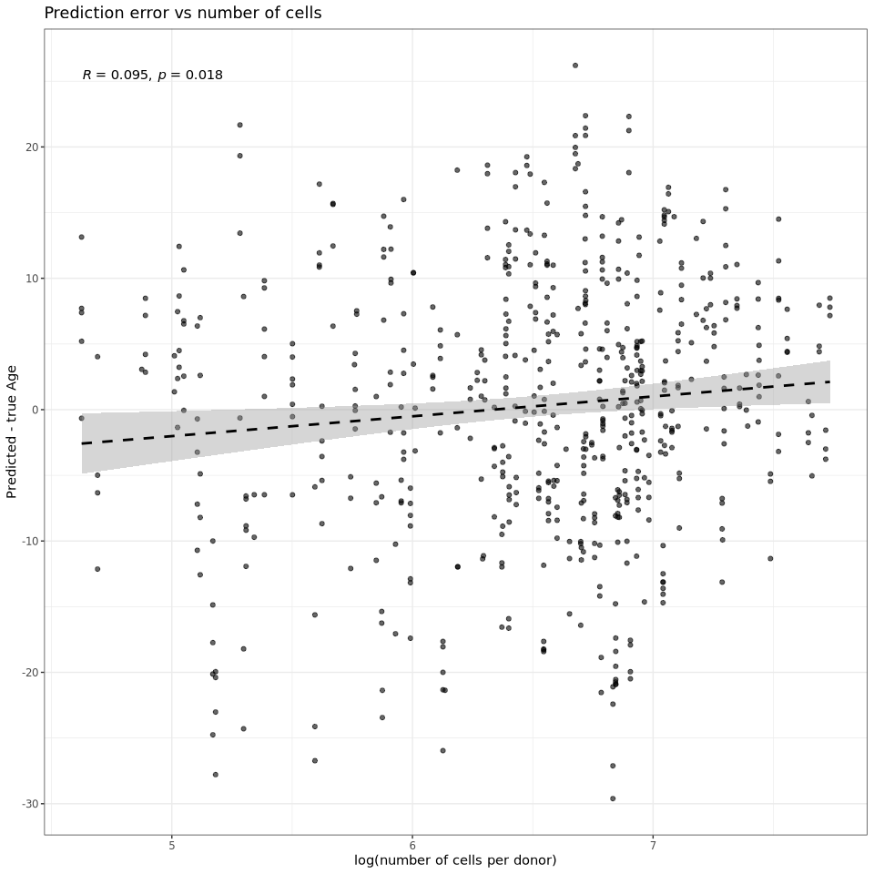

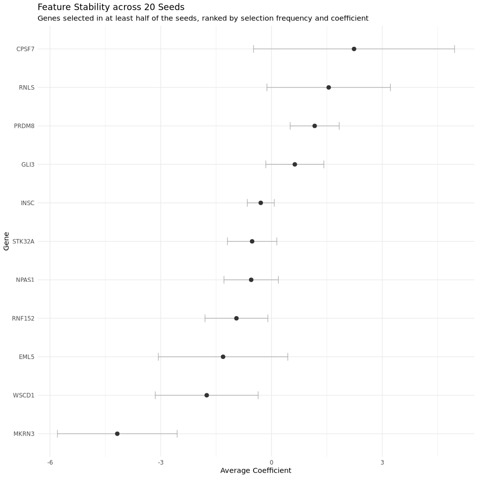

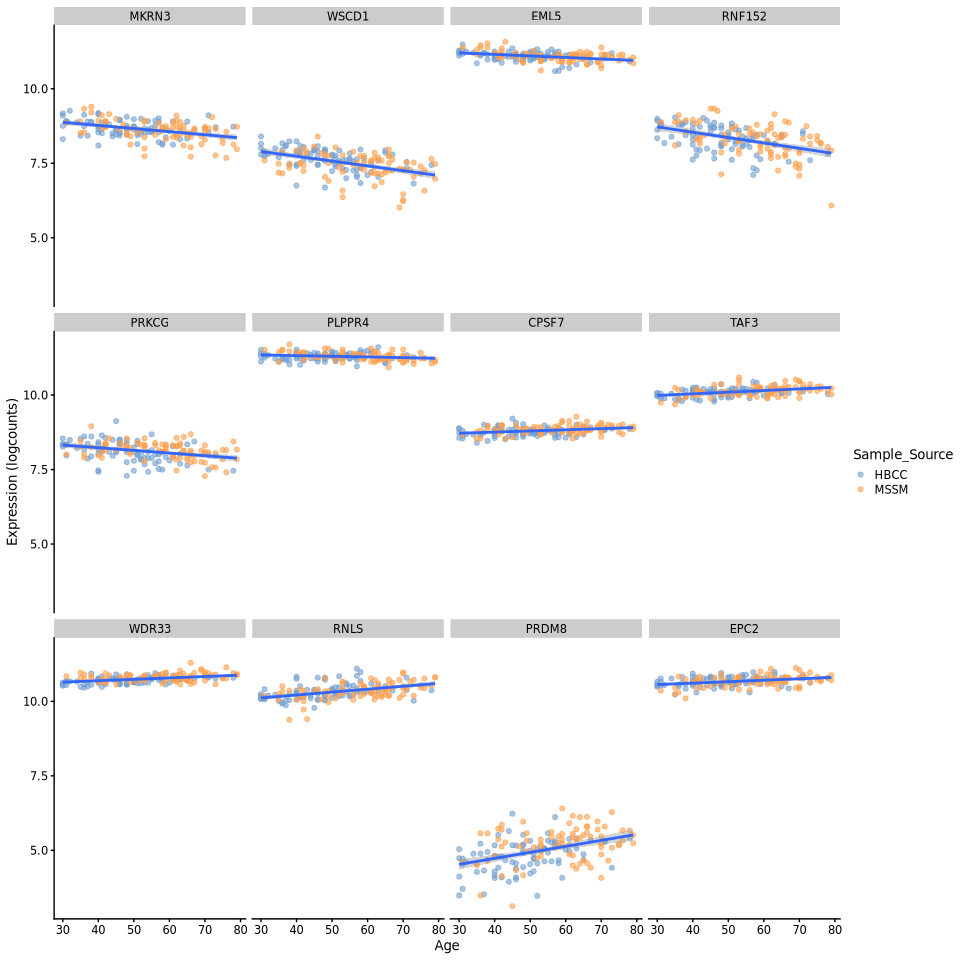

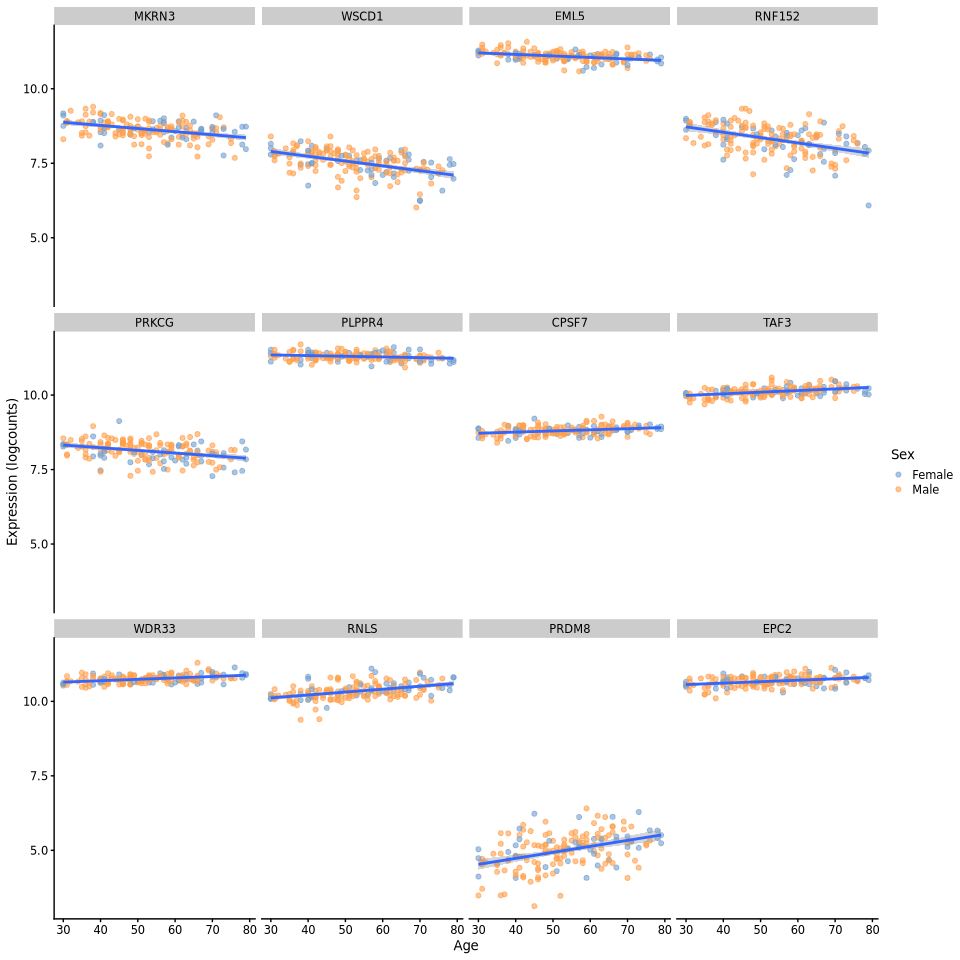

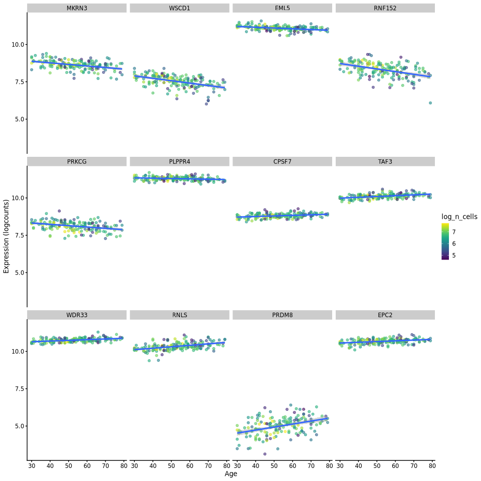

```r
result_IN = run_glmnet_age_model(
  sce = pseudobulk_sce_IN, n_times = n_times, label = "IN", output_dir = params$glmnet_output_dir,
  DEA_table = DEA_pseudobulk_IN, top_n_genes = params$top_n_genes_for_expression_plots
)
```

**EN**

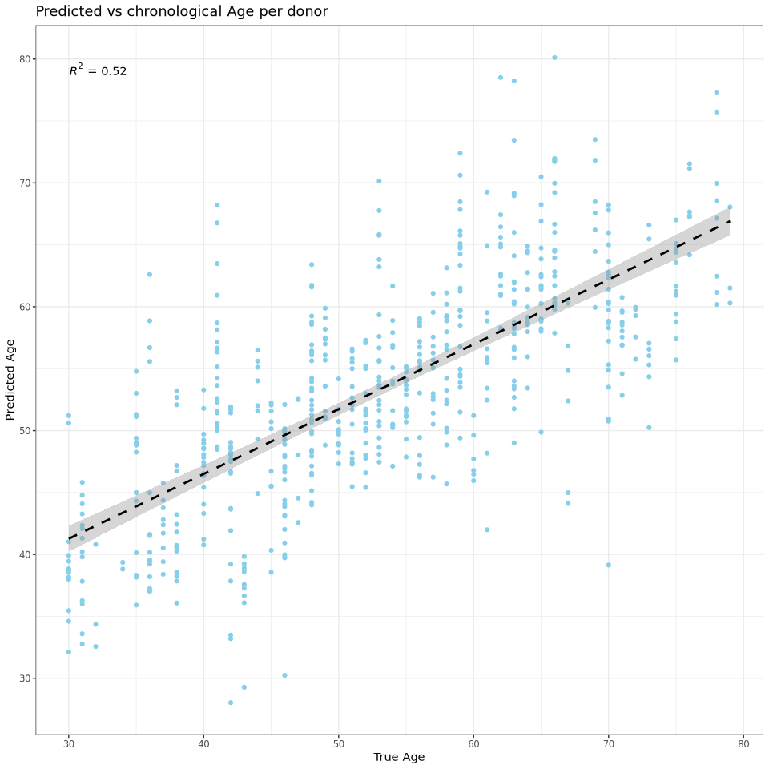

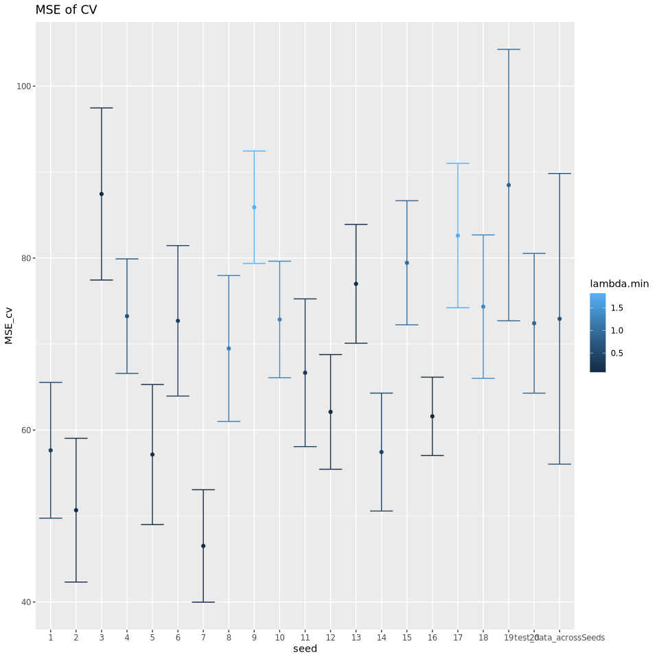

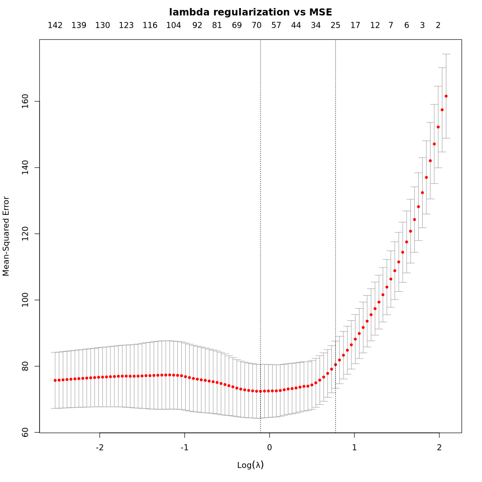

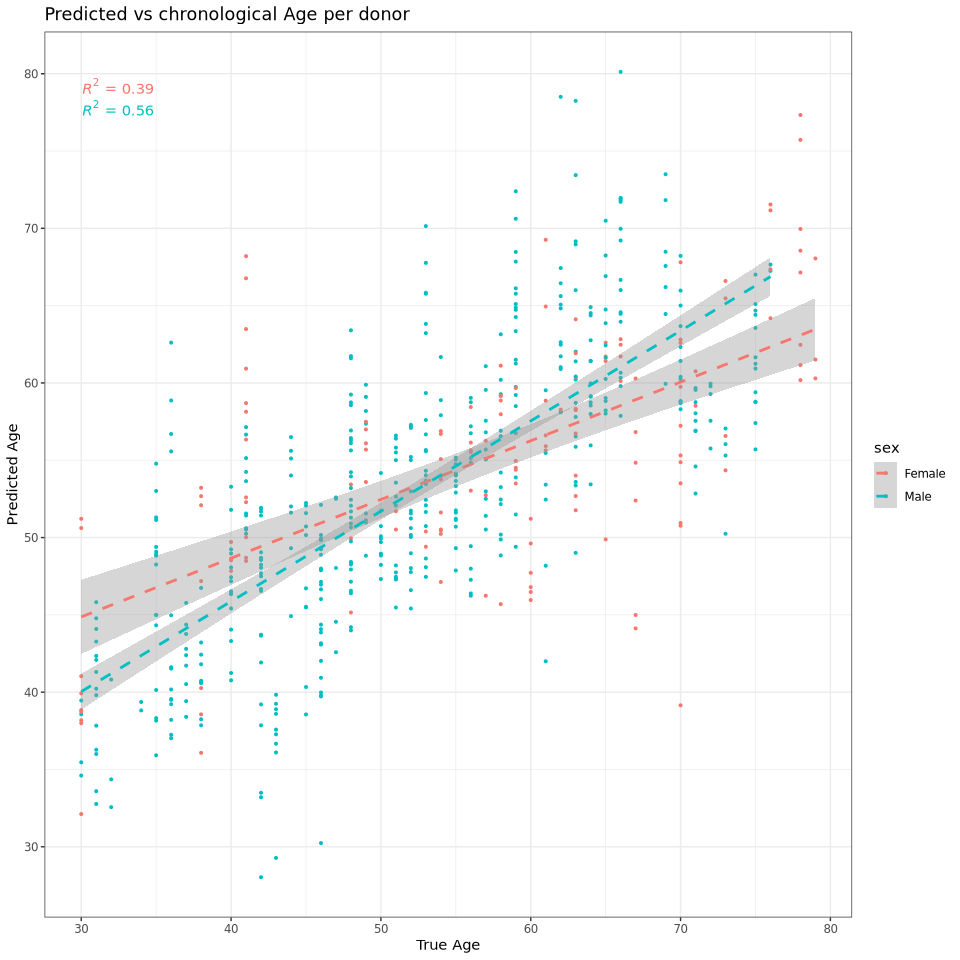

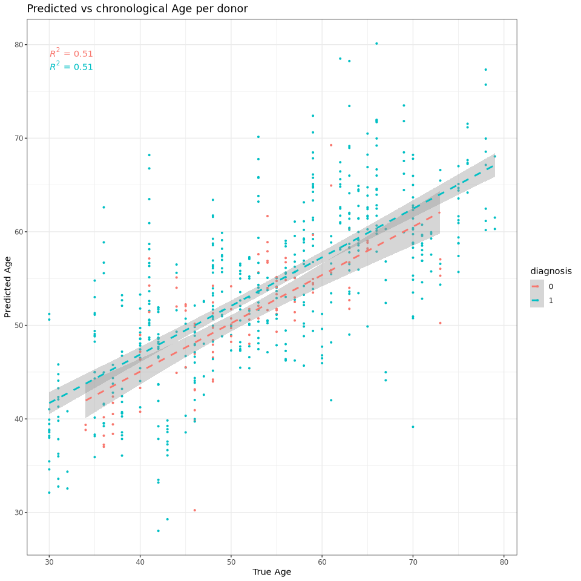

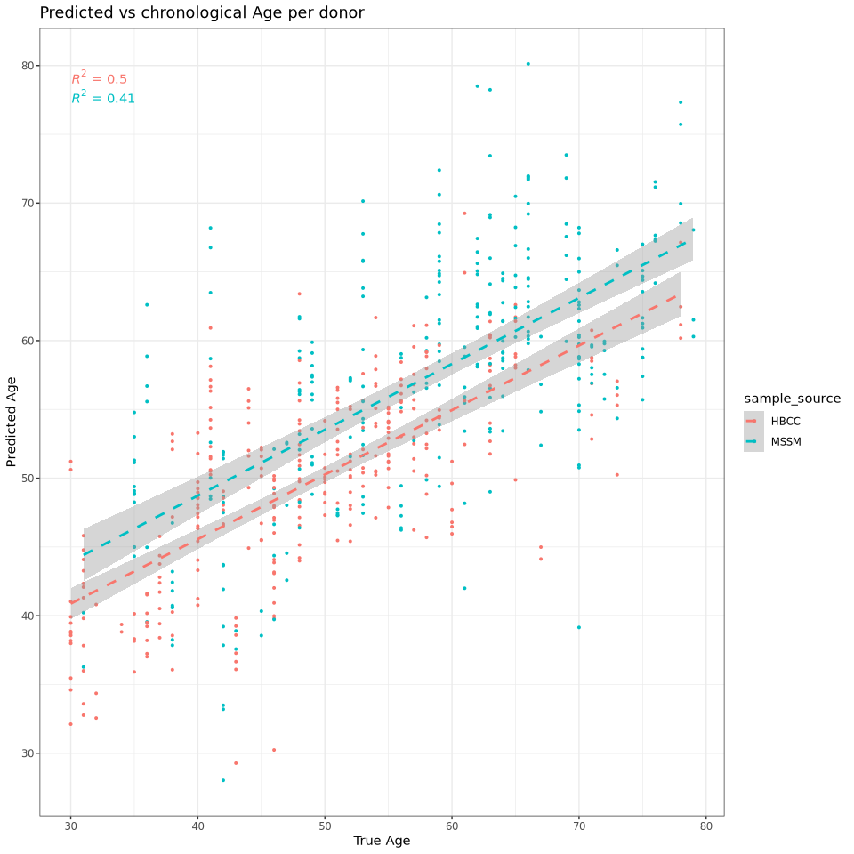

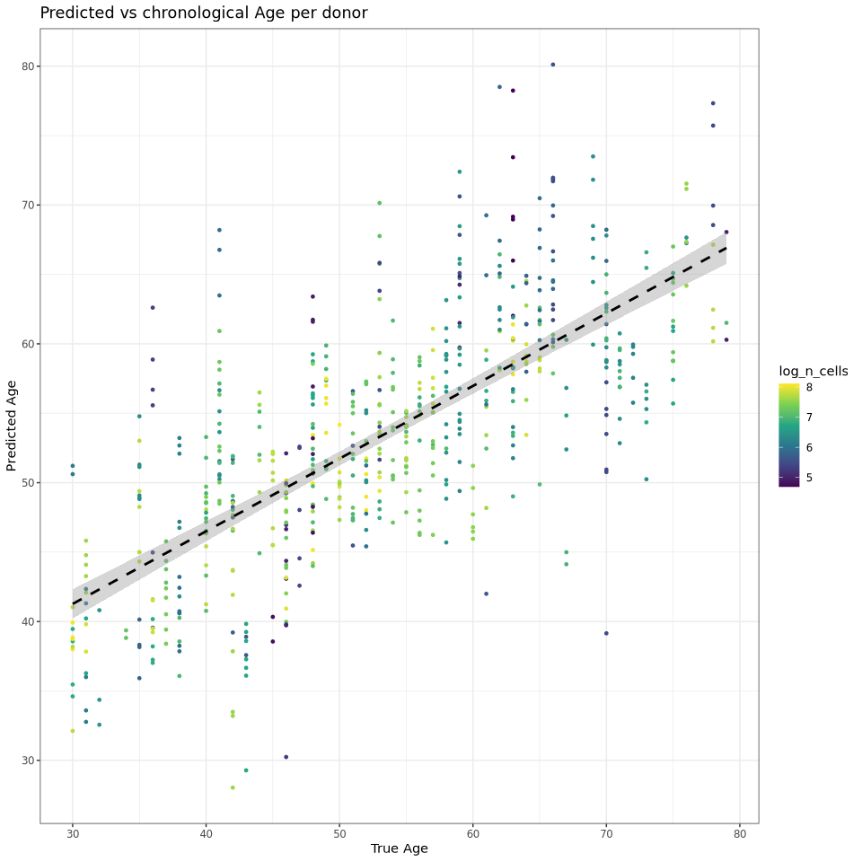

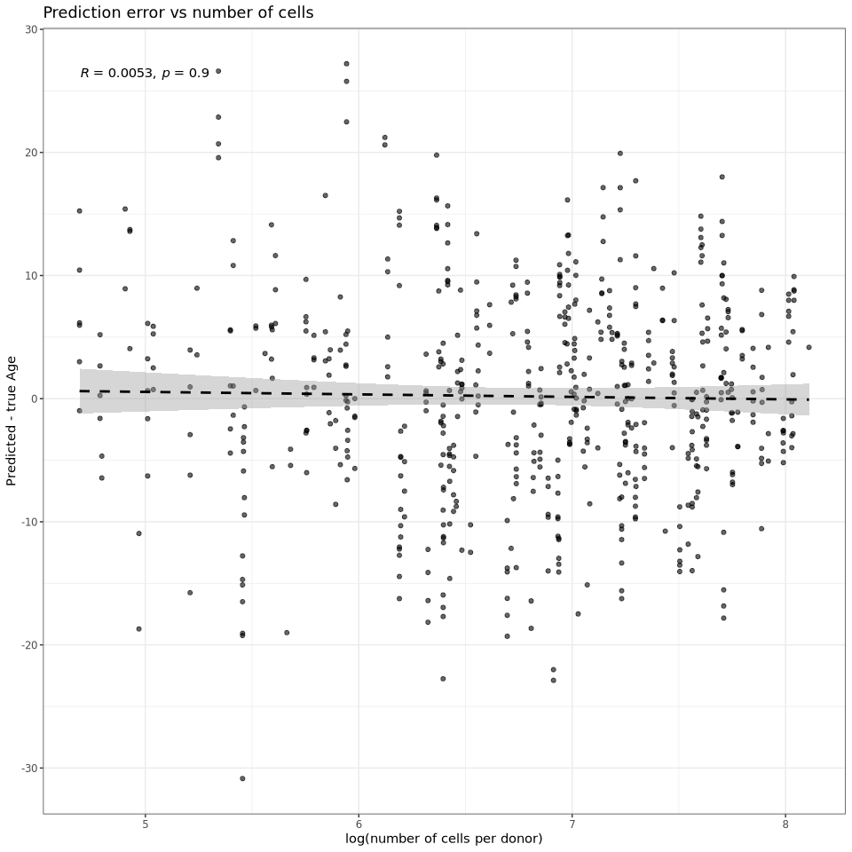

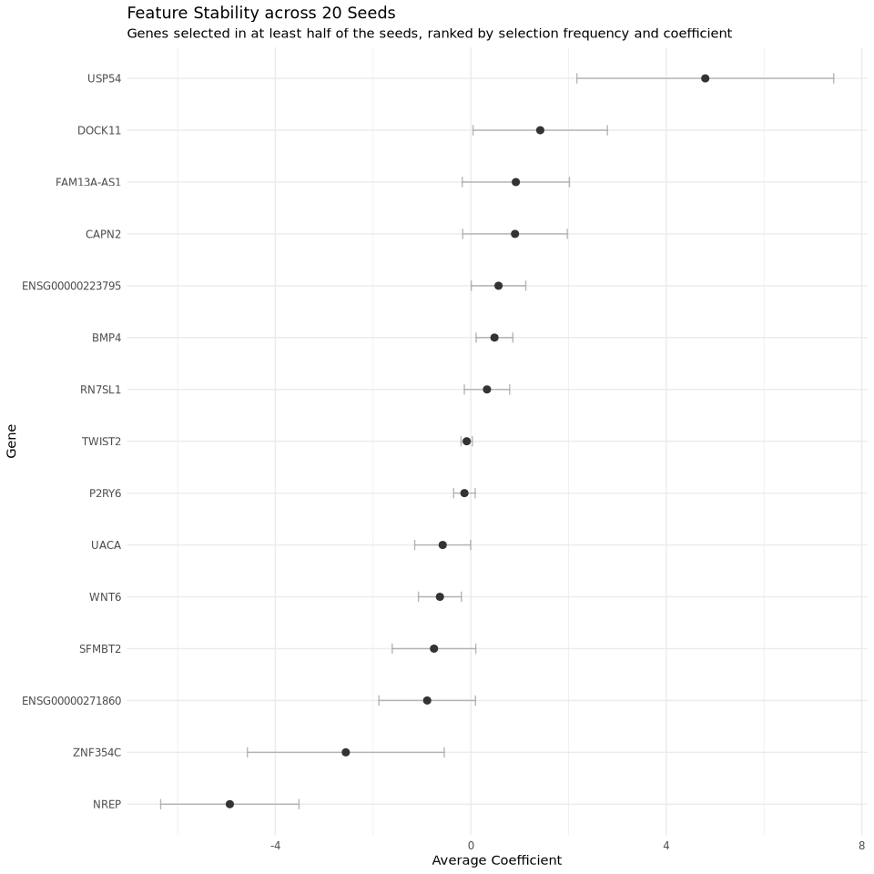

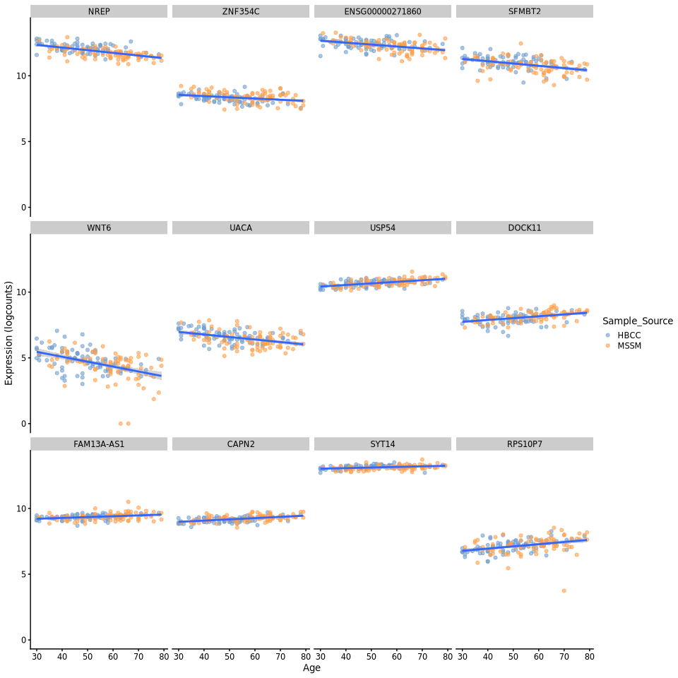

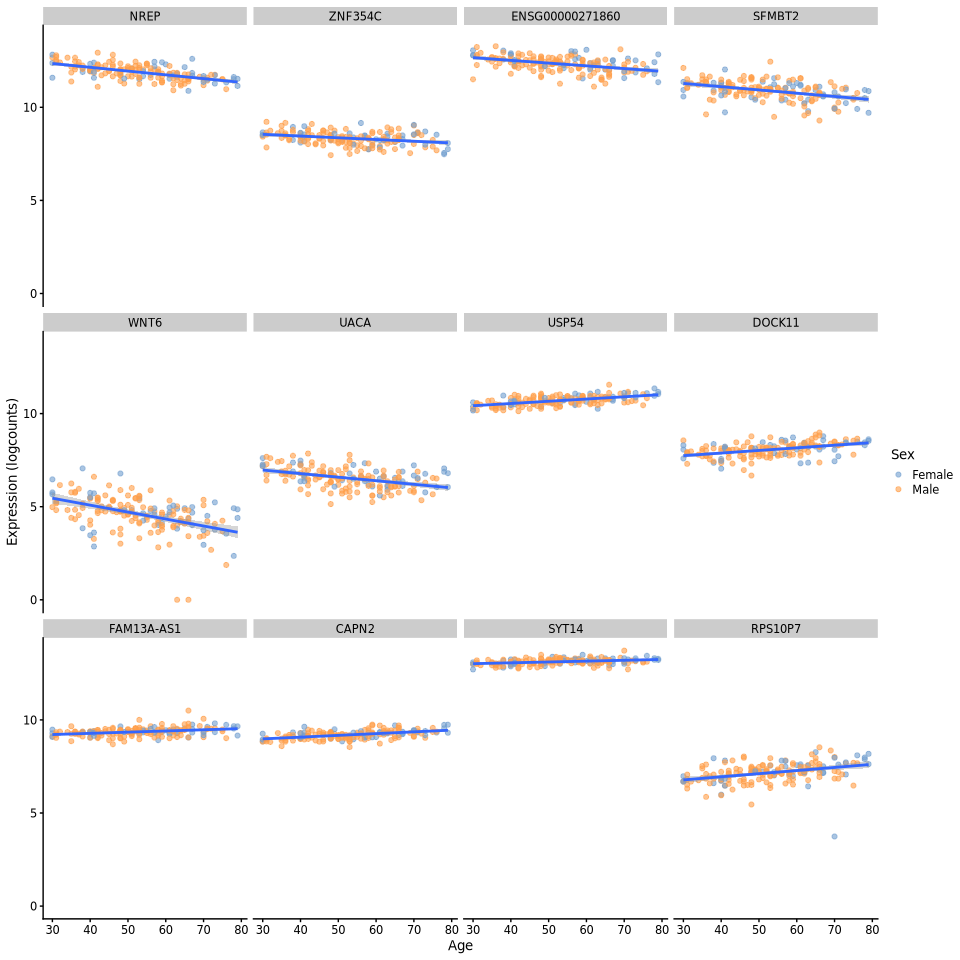

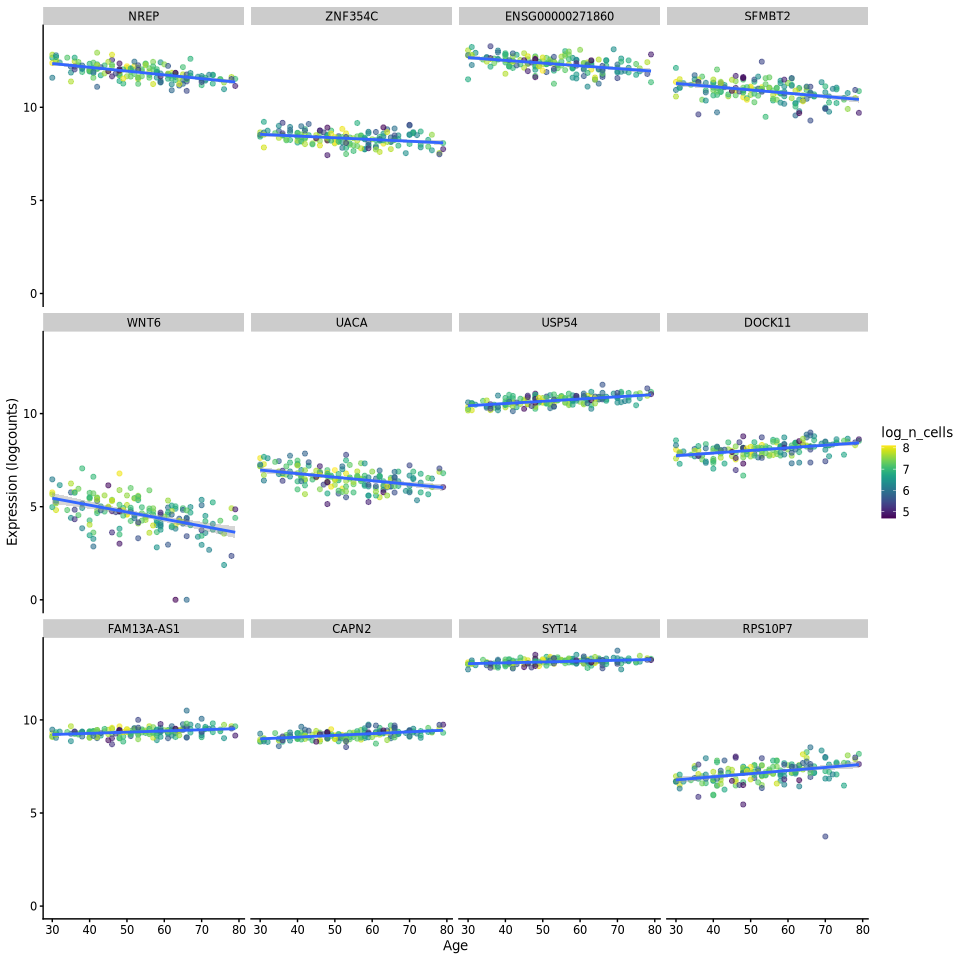

```r
result_EN = run_glmnet_age_model(
  sce = pseudobulk_sce_EN, n_times = n_times, label = "EN", output_dir = params$glmnet_output_dir,
  DEA_table = DEA_pseudobulk_EN, top_n_genes = params$top_n_genes_for_expression_plots
)
```